# Модель бинарного выбора

> Сейчас попробуем подружиться с моделями бинарного выбора на основе данных `bwght.dta`, где зависимая переменная отражает, является индивид курильщиком или нет.

## r

Загрузим необходимы пакеты.

```r
library(rio) # импорт и экспорт данных в разных форматах
library(tidyverse) # графики и манипуляции с данными
library(skimr) # описательные статистики
library(mfx) # нахождение предельных эффектов
library(margins) # визуализация предельных эффектов
library(lmtest) # проведение тестов
library(plotROC) # построение ROC-кривой
library(caret) # confusion-матрица
library(texreg) # вывод результатов регрессии в тех и html
```

Импортируем исследуемые данные.

```r
data = import("data/bwght.dta")
```

Сгенерируем переменную `smoke`, отражающее состояние отдельного индивида: курильщик, если `smoke = 1`, не курильщик - иначе.

```r
data = mutate(data, smoke=(cigs>0))
```

Рассмотрим описательные статистики по всем переменным: решение курить, семейный доход, налог на сигареты, цена сигарет, образование отца и матери, паритет, цвет кожи.

```r
skim(data)
```

```
Skim summary statistics
 n obs: 1388
 n variables: 15

-- Variable type:logical ---------------------------------------
 variable missing complete    n mean                      count
    smoke       0     1388 1388 0.15 FAL: 1176, TRU: 212, NA: 0

-- Variable type:numeric ---------------------------------------
 variable missing complete    n   mean    sd     p0    p25    p50    p75
    bwght       0     1388 1388 118.7  20.35  23    107    120    132
 bwghtlbs       0     1388 1388   7.42  1.27   1.44   6.69   7.5    8.25
 cigprice       0     1388 1388 130.56 10.24 103.8  122.8  130.8  137
     cigs       0     1388 1388   2.09  5.97   0      0      0      0
   cigtax       0     1388 1388  19.55  7.8    2     15     20     26
   faminc       0     1388 1388  29.03 18.74   0.5   14.5   27.5   37.5
 fatheduc     196     1192 1388  13.19  2.75   1     12     12     16
   lbwght       0     1388 1388   4.76  0.19   3.14   4.67   4.79   4.88
  lfaminc       0     1388 1388   3.07  0.92  -0.69   2.67   3.31   3.62
     male       0     1388 1388   0.52  0.5    0      0      1      1
 motheduc       1     1387 1388  12.94  2.38   2     12     12     14
    packs       0     1388 1388   0.1   0.3    0      0      0      0
   parity       0     1388 1388   1.63  0.89   1      1      1      2
    white       0     1388 1388   0.78  0.41   0      1      1      1
   p100     hist
 271    ▁▁▆▇▁▁▁▁
  16.94 ▁▁▆▇▁▁▁▁
 152.5  ▂▁▃▇▅▇▁▂
  50    ▇▁▁▁▁▁▁▁
  38    ▂▅▃▇▅▇▂▂
  65    ▆▆▇▇▃▅▁▆
  18    ▁▁▁▁▂▇▂▅
   5.6  ▁▁▁▁▃▇▁▁
   4.17 ▁▁▁▁▂▅▇▇
   1    ▇▁▁▁▁▁▁▇
  18    ▁▁▁▂▇▃▃▁
   2.5  ▇▁▁▁▁▁▁▁
   6    ▇▃▁▂▁▁▁▁
   1    ▂▁▁▁▁▁▁▇
```

Заметим существование пропущенных переменных у `fatheduc`, `motheduc`. Будем анализировать только те значения, у которых нет пропущенных наблюдений. Для этого создадим новый dataframe, `data_2`, в котором отсутствуют пропущенные значения. Просмотрим его описательные статистики.

```r
data_2 = filter(data, !is.na(fatheduc), !is.na(motheduc))
skim(data_2)
```

```
Skim summary statistics
 n obs: 1191
 n variables: 15

-- Variable type:logical ---------------------------------------
 variable missing complete    n mean                      count
    smoke       0     1191 1191 0.14 FAL: 1030, TRU: 161, NA: 0

-- Variable type:numeric ---------------------------------------
 variable missing complete    n    mean    sd     p0    p25    p50    p75
    bwght       0     1191 1191 119.53  20.14  23    108    120    132
 bwghtlbs       0     1191 1191   7.47   1.26   1.44   6.75   7.5    8.25
 cigprice       0     1191 1191 130.71  10.35 103.8  122.8  130.8  137
     cigs       0     1191 1191   1.77   5.34   0      0      0      0
   cigtax       0     1191 1191  19.6    7.86   2     15     20     26
   faminc       0     1191 1191  32.22  17.96   0.5   18.5   27.5   42.5
 fatheduc       0     1191 1191  13.19   2.74   1     12     12     16
   lbwght       0     1191 1191   4.77   0.19   3.14   4.68   4.79   4.88
  lfaminc       0     1191 1191   3.28   0.72  -0.69   2.92   3.31   3.75
     male       0     1191 1191   0.52   0.5    0      0      1      1
 motheduc       0     1191 1191  13.13   2.42   2     12     12     15
    packs       0     1191 1191   0.088  0.27   0      0      0      0
   parity       0     1191 1191   1.61   0.87   1      1      1      2
    white       0     1191 1191   0.84   0.36   0      1      1      1
   p100     hist
 271    ▁▁▆▇▁▁▁▁
  16.94 ▁▁▆▇▁▁▁▁
 152.5  ▂▁▃▇▅▇▁▂
  40    ▇▁▁▁▁▁▁▁
  38    ▂▅▃▇▆▇▂▂
  65    ▂▅▇▇▃▅▁▆
  18    ▁▁▁▁▂▇▂▅
   5.6  ▁▁▁▁▂▇▁▁
   4.17 ▁▁▁▁▁▃▇▇
   1    ▇▁▁▁▁▁▁▇
  18    ▁▁▁▂▇▃▃▂
   2    ▇▁▁▁▁▁▁▁
   6    ▇▃▁▂▁▁▁▁
   1    ▂▁▁▁▁▁▁▇
```

Построим модель линейной вероятности. Сохраним результат под `lin_prob_model`.

```r
lin_prob_model = lm(smoke ~ 1 + faminc + cigtax + cigprice + fatheduc + motheduc + parity + white, data=data_2)
summary(lin_prob_model)
```

```
Call:
lm(formula = smoke ~ 1 + faminc + cigtax + cigprice + fatheduc +
    motheduc + parity + white, data = data_2)

Residuals:
     Min       1Q   Median       3Q      Max
-0.46295 -0.17696 -0.11495 -0.02127  1.01628

Coefficients:
              Estimate Std. Error t value Pr(>|t|)
(Intercept)  0.4297071  0.2270444   1.893   0.0587 .
faminc      -0.0014813  0.0006325  -2.342   0.0193 *
cigtax       0.0008334  0.0026320   0.317   0.7516
cigprice     0.0007472  0.0019954   0.374   0.7081
fatheduc    -0.0064880  0.0047493  -1.366   0.1722
motheduc    -0.0242416  0.0053373  -4.542 6.14e-06 ***
parity       0.0019565  0.0110725   0.177   0.8598
white        0.0471603  0.0273790   1.723   0.0852 .
---
Signif. codes:  0 '***' 0.001 '**' 0.01 '*' 0.05 '.' 0.1 ' ' 1

Residual standard error: 0.3318 on 1183 degrees of freedom
Multiple R-squared:  0.06448,   Adjusted R-squared:  0.05895
F-statistic: 11.65 on 7 and 1183 DF,  p-value: 2.184e-14
```

Посмотрим на число совпадений прогноза и исходных значений. Для этого оценим предсказанные значения модели линейной вероятности. Сохраним значение как `predictions_lin_prob_model`.

```r
predictions_lin_prob_model = predict(lin_prob_model)
```

Генерируем `smoke_ols` как 1, если вероятность по модели больше 0.5 и 0, если она меньше 0.5.

```r
smoke_ols = 1 * (predictions_lin_prob_model>0.5)
```

Число совпадений данных и прогноза модели линейной вероятности:

```r
sum (smoke_ols == data_2$smoke)
```

```
[1] 1030
```

Известно, что модель линейной вероятности обладает значительными недостатками, в частности: нереалистичное значение оцененной вероятности, ошибки, распределённые не нормально и гетероскедастичность. Поэтому оценим `P(smoke=1|x)`, и построим логит- и пробит-модели. Немного о логит-модели: предполагается, что существует скрытая (латентная) переменная, для которой строится модель,
$$y^*_i = \beta_1 + \beta_2 \cdot X_i + \varepsilon_i$$
,так, что:

$$\begin{equation*}
Y_i =
\begin{cases}
1, &\text{если ${y_i}^* \geqslant 0$}\\
0, &\text{если ${y_i}^* < 0$}
\end{cases}
\end{equation*}$$

$$\varepsilon_i \sim logistic, \\f(t) = \frac{e^{-t}}{(1 + e^{-t})^2}$$

Построим логит-модель и сохраним результат оцененной модели как `logit_model`.

```r
logit_model = glm(smoke ~ 1 + faminc + cigtax + cigprice + fatheduc + motheduc + parity + white, x=TRUE, data=data_2, family=binomial(link="logit"))
summary(logit_model)
```

```
Call:
glm(formula = smoke ~ 1 + faminc + cigtax + cigprice + fatheduc +
    motheduc + parity + white, family = binomial(link = "logit"),
    data = data_2, x = TRUE)

Deviance Residuals:
    Min       1Q   Median       3Q      Max
-1.5699  -0.5878  -0.4379  -0.2854   2.6434

Coefficients:
             Estimate Std. Error z value Pr(>|z|)
(Intercept)  0.960628   2.083625   0.461  0.64477
faminc      -0.017142   0.006401  -2.678  0.00741 **
cigtax       0.013859   0.024435   0.567  0.57058
cigprice     0.004156   0.018280   0.227  0.82014
fatheduc    -0.054616   0.041813  -1.306  0.19148
motheduc    -0.224467   0.049228  -4.560 5.12e-06 ***
parity      -0.008435   0.097275  -0.087  0.93090
white        0.436632   0.260283   1.678  0.09344 .
---
Signif. codes:  0 '***' 0.001 '**' 0.01 '*' 0.05 '.' 0.1 ' ' 1

(Dispersion parameter for binomial family taken to be 1)

    Null deviance: 943.55  on 1190  degrees of freedom
Residual deviance: 862.11  on 1183  degrees of freedom
AIC: 878.11

Number of Fisher Scoring iterations: 5
```

Так как коэффициенты логит- и пробит- моделей плохо интерпретируются, поскольку единицы измерения латентной переменной определить сложно, посчитаем предельные эффекты, то есть изменение вероятности решения курить с изменением фактора на 1 единицу.

Для предельного эффекта в средних значениях факторов:

```r
logitmfx(smoke ~ 1 + faminc + cigtax + cigprice + fatheduc + motheduc + parity + white, data=data_2, atmean=TRUE)
```

```
Call:
logitmfx(formula = smoke ~ 1 + faminc + cigtax + cigprice + fatheduc +
    motheduc + parity + white, data = data_2, atmean = TRUE)

Marginal Effects:
               dF/dx   Std. Err.       z     P>|z|
faminc   -0.00168111  0.00061396 -2.7382  0.006178 **
cigtax    0.00135920  0.00239324  0.5679  0.570081
cigprice  0.00040759  0.00179294  0.2273  0.820165
fatheduc -0.00535620  0.00409569 -1.3078  0.190953
motheduc -0.02201350  0.00469099 -4.6927 2.696e-06 ***
parity   -0.00082727  0.00953824 -0.0867  0.930885
white     0.03815415  0.02011210  1.8971  0.057818 .
---
Signif. codes:  0 '***' 0.001 '**' 0.01 '*' 0.05 '.' 0.1 ' ' 1

dF/dx is for discrete change for the following variables:

[1] "white"
```

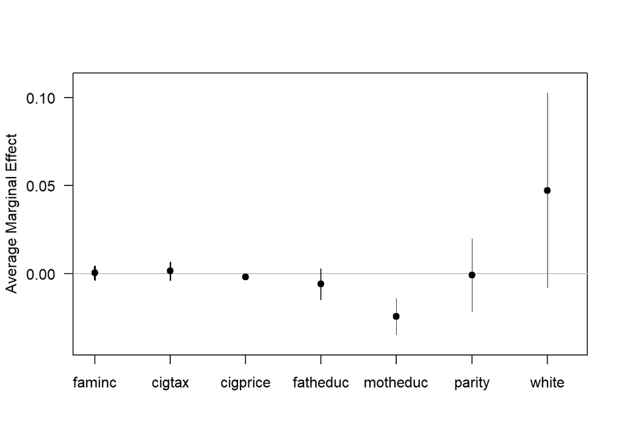

```r
margins = margins(logit_model)
plot(margins)
```

Интерпретация предельных эффектов следующая (на примере переменной семейного дохода): при увеличении семейного дохода в среднем на 1 единицу при остальных неизменных факторах, вероятность стать курильщиком уменьшается в среднем на 0.18%.

Визуализируем предельный эффект для семейного дохода:

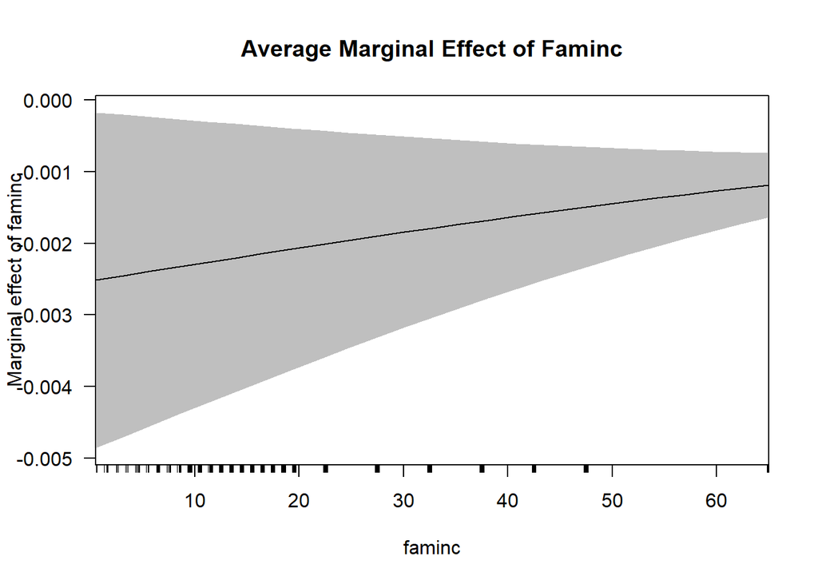

```r
cplot(logit_model, "faminc", what="effect", main="Average Marginal Effect of Faminc")
```

Для определения качества модели построим классификационную матрицу. Для этого сначала вычислим предсказания логит-модели, `predictions_logit_model`. Так как результат не бинарный, то введём порог отсечения, равный 0.5. Назовём бинарный результат `smoke_logit`:

```r
predictions_logit_model = predict(logit_model)
smoke_logit_model = (predictions_logit_model>0.5)
```

Построим классификационную матрицу. При возникновении ошибок аргументов, в частности, при несовпадении их размера или типа, можно воспользоваться функцией `as.factor()`.

```r
confusionMatrix(as.factor(smoke_logit_model), as.factor(data_2$smoke))
```

```
Confusion Matrix and Statistics

          Reference
Prediction FALSE TRUE
     FALSE  1029  161
     TRUE      1    0

               Accuracy : 0.864
                 95% CI : (0.8432, 0.883)
    No Information Rate : 0.8648
    P-Value [Acc > NIR] : 0.5546

                  Kappa : -0.0017

 Mcnemar's Test P-Value : <2e-16

            Sensitivity : 0.9990
            Specificity : 0.0000
         Pos Pred Value : 0.8647
         Neg Pred Value : 0.0000
             Prevalence : 0.8648
         Detection Rate : 0.8640
   Detection Prevalence : 0.9992
      Balanced Accuracy : 0.4995

       'Positive' Class : FALSE
```

Качество модели также можно проанализировать с помощью ROC-кривой, отражающей зависимость доли верных положительно классифицируемых наблюдений (`sensitivity`) от доли ложных положительно классифицируемых наблюдений `(1-specifity)`.

Построим ROC-кривую для логит-модели:

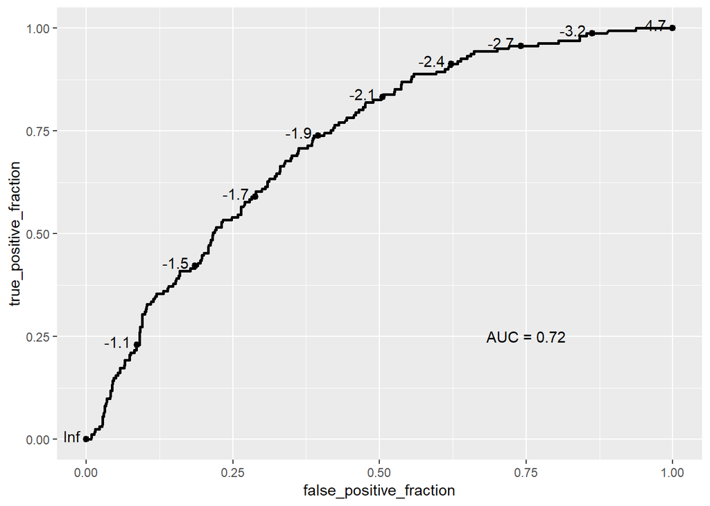

```r
basicplot = ggplot(data_2, aes(m=predictions_logit_model, d=data_2$smoke)) + geom_roc()
basicplot + annotate("text", x = .75, y = .25,
           label = paste("AUC =", round(calc_auc(basicplot)$AUC, 2)))
```

Площадь под кривой обозначается как AUC. Он показывает качество классификации. Соответственно, чем выше AUC, тем лучше построенная модель.

Теперь рассмотрим логит-модель, не учитывающую переменную `white`. Сохраним эту логит-модель под названием `logit_model_new`.

```r
logit_model_new = glm(smoke ~ 1 + faminc + cigtax + cigprice + fatheduc + motheduc + parity, x=TRUE, data=data_2, family=binomial(link="logit"))
```

Сравним модели `logit_model` и `logit_model_new` с помощью теста максимального правдоподобия (likelihood ratio test).

```r
lrtest(logit_model,logit_model_new)
```

```
Likelihood ratio test

Model 1: smoke ~ 1 + faminc + cigtax + cigprice + fatheduc + motheduc +
    parity + white
Model 2: smoke ~ 1 + faminc + cigtax + cigprice + fatheduc + motheduc +
    parity
  #Df  LogLik Df  Chisq Pr(>Chisq)
1   8 -431.06
2   7 -432.55 -1 2.9988    0.08333 .
---
Signif. codes:  0 '***' 0.001 '**' 0.01 '*' 0.05 '.' 0.1 ' ' 1
```

`p-value = 0.08` в LR-тесте. Следовательно, основная гипотеза о том, что переменная `white` не влияет на решение стать курильщиком, не отвергается на 5% уровне значимости.

Сейчас посмотрим на пробит-модель. Скрытая переменная в этой модели распределена стандартно нормально:
$$f(t) = \frac{1 \cdot e^{\frac{-t^2}{2}}}{\sqrt{2 \cdot \pi}}$$

Построим пробит-модель.

```r
probit_model = glm(smoke ~ 1 + faminc + cigtax + cigprice + fatheduc + motheduc + parity + white, data=data_2, family=binomial(link="probit"))
summary(probit_model)
```

```
Call:
glm(formula = smoke ~ 1 + faminc + cigtax + cigprice + fatheduc +
    motheduc + parity + white, family = binomial(link = "probit"),
    data = data_2)

Deviance Residuals:
    Min       1Q   Median       3Q      Max
-1.5255  -0.5947  -0.4376  -0.2607   2.7564

Coefficients:
             Estimate Std. Error z value Pr(>|z|)
(Intercept)  0.393063   1.130957   0.348  0.72818
faminc      -0.008873   0.003376  -2.628  0.00858 **
cigtax       0.005892   0.013245   0.445  0.65643
cigprice     0.003561   0.009930   0.359  0.71987
fatheduc    -0.034593   0.023160  -1.494  0.13527
motheduc    -0.125693   0.027090  -4.640 3.49e-06 ***
parity      -0.003052   0.053610  -0.057  0.95460
white        0.242348   0.140052   1.730  0.08356 .
---
Signif. codes:  0 '***' 0.001 '**' 0.01 '*' 0.05 '.' 0.1 ' ' 1

(Dispersion parameter for binomial family taken to be 1)

    Null deviance: 943.55  on 1190  degrees of freedom
Residual deviance: 858.93  on 1183  degrees of freedom
AIC: 874.93

Number of Fisher Scoring iterations: 5
```

Вычисление предельных эффектов и их интерпретация, построение классификационной матрицы и ROC-кривой и LR-тест проводятся аналогично выполненным в логит-модели. Выведем сравнительную таблицу для построенных моделей.

```r
screenreg(list(lin_prob_model, logit_model, probit_model),
             custom.model.names = c("Модель линейной   вероятности", "Логит-модель", "Пробит-модель"))
```

```
==========================================================================
                Модель линейной   вероятности  Логит-модель  Пробит-модель
--------------------------------------------------------------------------
(Intercept)        0.43                           0.96          0.39
                  (0.23)                         (2.08)        (1.13)
faminc            -0.00 *                        -0.02 **      -0.01 **
                  (0.00)                         (0.01)        (0.00)
cigtax             0.00                           0.01          0.01
                  (0.00)                         (0.02)        (0.01)
cigprice           0.00                           0.00          0.00
                  (0.00)                         (0.02)        (0.01)
fatheduc          -0.01                          -0.05         -0.03
                  (0.00)                         (0.04)        (0.02)
motheduc          -0.02 ***                      -0.22 ***     -0.13 ***
                  (0.01)                         (0.05)        (0.03)
parity             0.00                          -0.01         -0.00
                  (0.01)                         (0.10)        (0.05)
white              0.05                           0.44          0.24
                  (0.03)                         (0.26)        (0.14)
--------------------------------------------------------------------------
R^2                0.06
Adj. R^2           0.06
Num. obs.       1191                           1191          1191
RMSE               0.33
AIC                                             878.11        874.93
BIC                                             918.77        915.59
Log Likelihood                                 -431.06       -429.46
Deviance                                        862.11        858.93
==========================================================================
*** p < 0.001, ** p < 0.01, * p < 0.05
```

## python

Попробуем повторить эти шаги, используя **python**.

Импортируем пакеты:

```python
import numpy as np
import pandas as pd # чтение файлов
import matplotlib.pyplot as plt # построение графиков
from statsmodels.formula.api import logit, probit, ols # построение логит-, пробит - и линейной регрессий
import statistics # описательные статистики
import sklearn
from sklearn import metrics # для работы с классификационными матрицами
from sklearn.metrics import roc_curve, auc  # ROC-curve и AUC
from scipy.stats.distributions import chi2 # хи-квадрат-статистика
```

Загрузим данные:

```python
data = pd.read_stata("data/bwght.dta")
```

Уберём пропущенные данные.Выведем описательные статистики по данным.

```python
data_2 = data.dropna()
data_2.describe()
```

```
            faminc       cigtax  ...        packs      lfaminc
count  1191.000000  1191.000000  ...  1191.000000  1191.000000
mean     32.219143    19.603275  ...     0.088455     3.276758
std      17.956198     7.859844  ...     0.267189     0.715159
min       0.500000     2.000000  ...     0.000000    -0.693147
25%      18.500000    15.000000  ...     0.000000     2.917771
50%      27.500000    20.000000  ...     0.000000     3.314186
75%      42.500000    26.000000  ...     0.000000     3.749504
max      65.000000    38.000000  ...     2.000000     4.174387

[8 rows x 14 columns]
```

Создадим бинарную переменную `smoke`:

```python
data_2['smoke'] = 1 * (data_2['cigs']>0)
```

Построим модель линейной вероятности:

```python
lin_prob_model = ols("smoke ~ 1 + faminc + cigtax + cigprice + fatheduc + motheduc + parity + white", data_2).fit()
lin_prob_model.summary()
```

```
<class 'statsmodels.iolib.summary.Summary'>
"""
                            OLS Regression Results
==============================================================================
Dep. Variable:                  smoke   R-squared:                       0.064
Model:                            OLS   Adj. R-squared:                  0.059
Method:                 Least Squares   F-statistic:                     11.65
Date:                Tue, 14 Jan 2020   Prob (F-statistic):           2.18e-14
Time:                        23:34:11   Log-Likelihood:                -372.09
No. Observations:                1191   AIC:                             760.2
Df Residuals:                    1183   BIC:                             800.8
Df Model:                           7
Covariance Type:            nonrobust
==============================================================================
                 coef    std err          t      P>|t|      [0.025      0.975]
------------------------------------------------------------------------------
Intercept      0.4297      0.227      1.893      0.059      -0.016       0.875
faminc        -0.0015      0.001     -2.342      0.019      -0.003      -0.000
cigtax         0.0008      0.003      0.317      0.752      -0.004       0.006
cigprice       0.0007      0.002      0.374      0.708      -0.003       0.005
fatheduc      -0.0065      0.005     -1.366      0.172      -0.016       0.003
motheduc      -0.0242      0.005     -4.542      0.000      -0.035      -0.014
parity         0.0020      0.011      0.177      0.860      -0.020       0.024
white          0.0472      0.027      1.723      0.085      -0.007       0.101
==============================================================================
Omnibus:                      400.127   Durbin-Watson:                   2.006
Prob(Omnibus):                  0.000   Jarque-Bera (JB):              939.987
Skew:                           1.901   Prob(JB):                    7.66e-205
Kurtosis:                       5.117   Cond. No.                     3.26e+03
==============================================================================

Warnings:
[1] Standard Errors assume that the covariance matrix of the errors is correctly specified.
[2] The condition number is large, 3.26e+03. This might indicate that there are
strong multicollinearity or other numerical problems.
"""
```

Создадим переменную `predictions__lin_prob_model`, равную прогнозным значениям модели линейной вероятности, и посмотрим на число совпадений исходных и прогнозных данных.

```python
predictions_lin_prob_model = lin_prob_model.predict(data_2)
data_2['smoke_ols'] = 1 * (predictions_lin_prob_model>0.5)
sum(data_2['smoke']==data_2['smoke_ols'])
```

```
1030
```

Построим логит-модель.

```python
logit_model = logit("smoke ~ 1 + faminc + cigtax + cigprice + fatheduc + motheduc + parity + white", data_2).fit()
```

```
Optimization terminated successfully.
         Current function value: 0.361927
         Iterations 7
```

```python
logit_model.summary()
```

```
<class 'statsmodels.iolib.summary.Summary'>
"""
                           Logit Regression Results
==============================================================================
Dep. Variable:                  smoke   No. Observations:                 1191
Model:                          Logit   Df Residuals:                     1183
Method:                           MLE   Df Model:                            7
Date:                Tue, 14 Jan 2020   Pseudo R-squ.:                 0.08631
Time:                        23:34:12   Log-Likelihood:                -431.06
converged:                       True   LL-Null:                       -471.78
                                        LLR p-value:                 6.999e-15
==============================================================================
                 coef    std err          z      P>|z|      [0.025      0.975]
------------------------------------------------------------------------------
Intercept      0.9606      2.084      0.461      0.645      -3.123       5.044
faminc        -0.0171      0.006     -2.678      0.007      -0.030      -0.005
cigtax         0.0139      0.024      0.567      0.571      -0.034       0.062
cigprice       0.0042      0.018      0.227      0.820      -0.032       0.040
fatheduc      -0.0546      0.042     -1.306      0.191      -0.137       0.027
motheduc      -0.2245      0.049     -4.560      0.000      -0.321      -0.128
parity        -0.0084      0.097     -0.087      0.931      -0.199       0.182
white          0.4366      0.260      1.678      0.093      -0.074       0.947
==============================================================================
"""
```

Посчитаем предельные эффекты в средних значениях переменных для логистической регрессии.

```python
me_mean = logit_model.get_margeff(at='mean')
me_mean.summary()
```

```
<class 'statsmodels.iolib.summary.Summary'>
"""
        Logit Marginal Effects
=====================================
Dep. Variable:                  smoke
Method:                          dydx
At:                              mean
==============================================================================
                dy/dx    std err          z      P>|z|      [0.025      0.975]
------------------------------------------------------------------------------
faminc        -0.0017      0.001     -2.738      0.006      -0.003      -0.000
cigtax         0.0014      0.002      0.568      0.570      -0.003       0.006
cigprice       0.0004      0.002      0.227      0.820      -0.003       0.004
fatheduc      -0.0054      0.004     -1.308      0.191      -0.013       0.003
motheduc      -0.0220      0.005     -4.693      0.000      -0.031      -0.013
parity        -0.0008      0.010     -0.087      0.931      -0.020       0.018
white          0.0428      0.025      1.684      0.092      -0.007       0.093
==============================================================================
"""
```

Посмотрим на точность классификации построенной логит-модели. Для этого вычислим прогнозные значения модели.

```python
predictions_logit_pred = logit_model.predict(data_2) # прогнозирование значений
data_2['smoke_logit_model'] = 1 * (predictions_logit_pred>0.5)
```

Построим классификационную матрицу.

```python
sklearn.metrics.confusion_matrix(data_2['smoke'], data_2['smoke_logit_model'])
```

```
array([[1027,    3],
       [ 161,    0]], dtype=int64)
```

Точность прогноза и классификационные данные.

```python
np.round(sklearn.metrics.accuracy_score(data_2['smoke'],data_2['smoke_logit_model']), 2)
```

```
0.86
```

```python
sklearn.metrics.classification_report(data_2['smoke'], data_2['smoke_logit_model'])
```

[output not shown]

Выведем ROC-кривую для логит-модели.

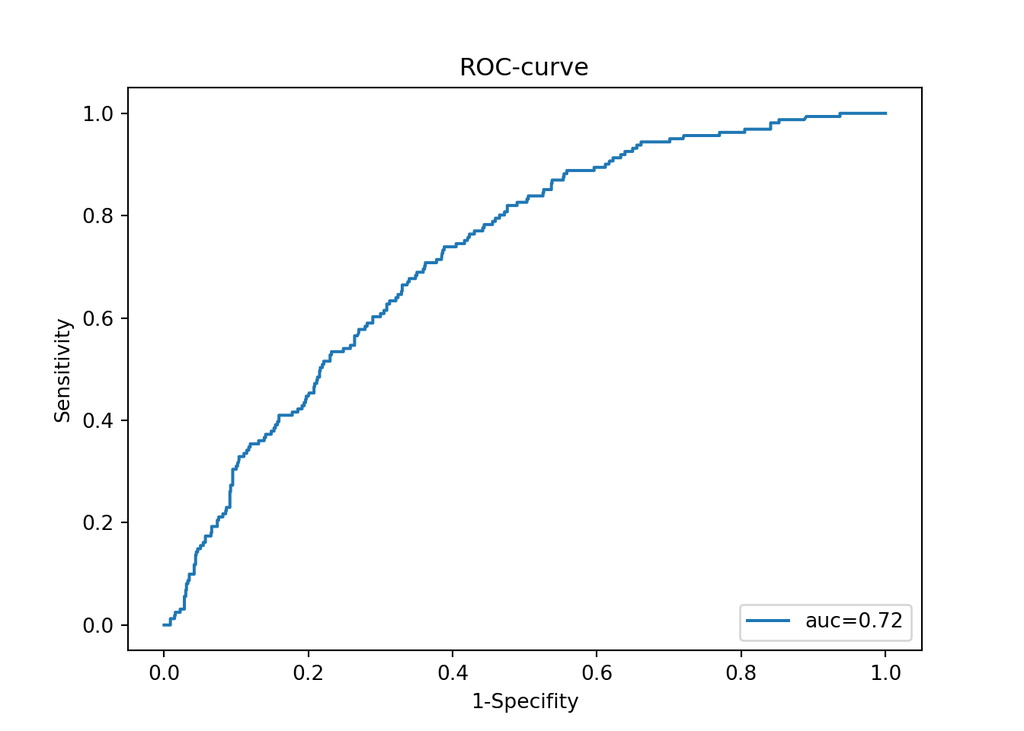

```python
fpr, tpr, thresholds = metrics.roc_curve(data_2['smoke'], predictions_logit_pred)
auc = metrics.roc_auc_score(data_2['smoke'], predictions_logit_pred)
plt.plot(fpr,tpr,label="auc="+str(np.round(auc, 2)))
plt.legend(loc=4)
plt.xlabel('1-Specifity')
plt.ylabel('Sensitivity')
plt.title('ROC-curve')
plt.show()
```

Построим новую логит-модель (`logit_model_new`) без учёта переменной `white`.

```python
logit_model_new = logit("smoke ~ 1 + faminc + cigtax + cigprice + fatheduc + motheduc + parity ", data_2).fit()
```

```
Optimization terminated successfully.
         Current function value: 0.363186
         Iterations 7
```

```python
logit_model_new.summary()
```

```
<class 'statsmodels.iolib.summary.Summary'>
"""
                           Logit Regression Results
==============================================================================
Dep. Variable:                  smoke   No. Observations:                 1191
Model:                          Logit   Df Residuals:                     1184
Method:                           MLE   Df Model:                            6
Date:                Tue, 14 Jan 2020   Pseudo R-squ.:                 0.08314
Time:                        23:34:14   Log-Likelihood:                -432.55
converged:                       True   LL-Null:                       -471.78
                                        LLR p-value:                 7.492e-15
==============================================================================
                 coef    std err          z      P>|z|      [0.025      0.975]
------------------------------------------------------------------------------
Intercept      1.5094      2.058      0.733      0.463      -2.524       5.543
faminc        -0.0152      0.006     -2.426      0.015      -0.027      -0.003
cigtax         0.0186      0.024      0.766      0.444      -0.029       0.066
cigprice       0.0019      0.018      0.103      0.918      -0.034       0.038
fatheduc      -0.0502      0.041     -1.217      0.224      -0.131       0.031
motheduc      -0.2298      0.049     -4.692      0.000      -0.326      -0.134
parity        -0.0183      0.097     -0.187      0.851      -0.209       0.173
==============================================================================
"""
```

Так как на момент написания коана готовой реализации функции теста отношения правдоподобия нет, то сделаем его ручками.

```python
L1 = logit_model.llf
L2 = logit_model_new.llf
def likelihood_ratio(llmin, llmax):
    return(2*(max(llmax, llmin) - min(llmax, llmin)))
LR = likelihood_ratio (L1, L2)
np.round(chi2.sf(LR, 1), 2) # расчёт p-value для теста
```

```
0.08
```

Основная гипотеза о незначимости фактора `white` не отвергается на 5% уровне значимости. Построим пробит-модель.

```python
probit_model = probit("smoke ~ 1 + faminc + cigtax + cigprice + fatheduc + motheduc + parity + white", data_2).fit()
```

```
Optimization terminated successfully.
         Current function value: 0.360591
         Iterations 6
```

```python
probit_model.summary()
```

```
<class 'statsmodels.iolib.summary.Summary'>
"""
                          Probit Regression Results
==============================================================================
Dep. Variable:                  smoke   No. Observations:                 1191
Model:                         Probit   Df Residuals:                     1183
Method:                           MLE   Df Model:                            7
Date:                Tue, 14 Jan 2020   Pseudo R-squ.:                 0.08969
Time:                        23:34:14   Log-Likelihood:                -429.46
converged:                       True   LL-Null:                       -471.78
                                        LLR p-value:                 1.566e-15
==============================================================================
                 coef    std err          z      P>|z|      [0.025      0.975]
------------------------------------------------------------------------------
Intercept      0.3931      1.115      0.352      0.725      -1.793       2.579
faminc        -0.0089      0.003     -2.622      0.009      -0.016      -0.002
cigtax         0.0059      0.013      0.447      0.655      -0.020       0.032
cigprice       0.0036      0.010      0.363      0.717      -0.016       0.023
fatheduc      -0.0346      0.023     -1.489      0.137      -0.080       0.011
motheduc      -0.1257      0.027     -4.622      0.000      -0.179      -0.072
parity        -0.0031      0.054     -0.057      0.955      -0.109       0.103
white          0.2423      0.140      1.735      0.083      -0.031       0.516
==============================================================================
"""
```

Расчёт предельных эффектов, точности классификации, визуализация ROC-кривой и проведение LR-теста проводятся аналогично операциям с логит-моделью. Сравнение моделей.

```python
pd.DataFrame(dict(col1=lin_prob_model.params, col2=logit_model.params, col3=probit_model.params))
```

```
               col1      col2      col3
Intercept  0.429707  0.960628  0.393063
faminc    -0.001481 -0.017142 -0.008873
cigtax     0.000833  0.013859  0.005892
cigprice   0.000747  0.004156  0.003561
fatheduc  -0.006488 -0.054616 -0.034593
motheduc  -0.024242 -0.224467 -0.125694
parity     0.001956 -0.008435 -0.003053
white      0.047160  0.436632  0.242348
```

## stata

А сейчас познакомимся с тем, как **stata** работает с моделями бинарного выбора.

Импортируем данные.

```stata
use data/bwght.dta
```

```
running C:\Users\Yuliya\Documents\GitHub\bdemeshev\Econometrics-Rosetta-Stone\julia_work\pro
> file.do . use data/bwght.dta
```

Сгенерируем переменную `smoke`.

```stata
gen smoke = (cigs>0) if cigs != .
```

```
running C:\Users\Yuliya\Documents\GitHub\bdemeshev\Econometrics-Rosetta-Stone\julia_work\pro
> file.do . gen smoke = (cigs>0) if cigs != .
```

Рассмотрим описательные статистики dataframe.

```stata
sum smoke faminc cigtax cigprice fatheduc motheduc parity white
```

```
running C:\Users\Yuliya\Documents\GitHub\bdemeshev\Econometrics-Rosetta-Stone\julia_work\pro
> file.do . sum smoke faminc cigtax cigprice fatheduc motheduc parity white

    Variable |       Obs        Mean    Std. Dev.       Min        Max
-------------+--------------------------------------------------------
       smoke |      1388    .1527378    .3598642          0          1
      faminc |      1388    29.02666    18.73928         .5         65
      cigtax |      1388    19.55295    7.795598          2         38
    cigprice |      1388     130.559    10.24448      103.8      152.5
    fatheduc |      1192    13.18624    2.745985          1         18
-------------+--------------------------------------------------------
    motheduc |      1387    12.93583    2.376728          2         18
      parity |      1388    1.632565    .8940273          1          6
       white |      1388    .7845821    .4112601          0          1
```

Уберём пропущенные наблюдения.

```stata
sum smoke faminc cigtax cigprice fatheduc motheduc parity white if fatheduc != . & motheduc != .
```

```
running C:\Users\Yuliya\Documents\GitHub\bdemeshev\Econometrics-Rosetta-Stone\julia_work\pro
> file.do . sum smoke faminc cigtax cigprice fatheduc motheduc parity white if fatheduc != . & mothedu
> c != .

    Variable |       Obs        Mean    Std. Dev.       Min        Max
-------------+--------------------------------------------------------
       smoke |      1191    .1351805    .3420599          0          1
      faminc |      1191    32.21914     17.9562         .5         65
      cigtax |      1191    19.60327    7.859844          2         38
    cigprice |      1191    130.7097    10.35128      103.8      152.5
    fatheduc |      1191    13.19144    2.741274          1         18
-------------+--------------------------------------------------------
    motheduc |      1191     13.1251    2.417437          2         18
      parity |      1191     1.61377    .8746352          1          6
       white |      1191    .8438287    .3631701          0          1
```

Построим модель линейной вероятности. Сохраним результат под `lin_prob_model`.

```stata
reg smoke faminc cigtax cigprice fatheduc motheduc parity white if fatheduc != . & motheduc != .
est store lin_prob_model
```

```
running C:\Users\Yuliya\Documents\GitHub\bdemeshev\Econometrics-Rosetta-Stone\julia_work\pro
> file.do . reg smoke faminc cigtax cigprice fatheduc motheduc parity white if fatheduc != . & mothedu
> c != .

      Source |       SS       df       MS              Number of obs =    1191
-------------+------------------------------           F(  7,  1183) =   11.65
       Model |  8.97813534     7  1.28259076           Prob > F      =  0.0000
    Residual |  130.257801  1183  .110108031           R-squared     =  0.0645
-------------+------------------------------           Adj R-squared =  0.0589
       Total |  139.235936  1190  .117004988           Root MSE      =  .33183

------------------------------------------------------------------------------
       smoke |      Coef.   Std. Err.      t    P>|t|     [95% Conf. Interval]
-------------+----------------------------------------------------------------
      faminc |  -.0014813   .0006325    -2.34   0.019    -.0027223   -.0002404
      cigtax |   .0008334    .002632     0.32   0.752    -.0043306    .0059974
    cigprice |   .0007472   .0019954     0.37   0.708    -.0031676    .0046621
    fatheduc |   -.006488   .0047493    -1.37   0.172    -.0158059    .0028299
    motheduc |  -.0242416   .0053373    -4.54   0.000    -.0347132   -.0137699
      parity |   .0019565   .0110725     0.18   0.860    -.0197675    .0236805
       white |   .0471603    .027379     1.72   0.085    -.0065564    .1008771
       _cons |   .4297071   .2270444     1.89   0.059    -.0157474    .8751616
------------------------------------------------------------------------------
```

Посчитаем количество совпадений прогнозов и исходных значений.

```stata
predict predictions_lin_prob_model
gen smoke_ols = (predictions_lin_prob_model>0.5) if predictions_lin_prob_model != .
count if smoke_ols == smoke
tab smoke_ols smoke
```

```
running C:\Users\Yuliya\Documents\GitHub\bdemeshev\Econometrics-Rosetta-Stone\julia_work\pro
> file.do . predict predictions_lin_prob_model
(option xb assumed; fitted values)
(197 missing values generated)

(197 missing values generated)

 1030

           |         smoke
 smoke_ols |         0          1 |     Total
-----------+----------------------+----------
         0 |     1,030        161 |     1,191
-----------+----------------------+----------
     Total |     1,030        161 |     1,191
```

Построим логит-модель и сохраним результат оцененной модели как `logit_model`.

```stata
logit smoke faminc cigtax cigprice fatheduc motheduc parity white if fatheduc != . & motheduc != .
est store logit_model
```

```
running C:\Users\Yuliya\Documents\GitHub\bdemeshev\Econometrics-Rosetta-Stone\julia_work\pro
> file.do . logit smoke faminc cigtax cigprice fatheduc motheduc parity white if fatheduc != . & mothe
> duc != .

Iteration 0:   log likelihood = -471.77574
Iteration 1:   log likelihood = -434.01279
Iteration 2:   log likelihood =  -431.0609
Iteration 3:   log likelihood = -431.05512
Iteration 4:   log likelihood = -431.05512

Logistic regression                               Number of obs   =       1191
                                                  LR chi2(7)      =      81.44
                                                  Prob > chi2     =     0.0000
Log likelihood = -431.05512                       Pseudo R2       =     0.0863

------------------------------------------------------------------------------
       smoke |      Coef.   Std. Err.      z    P>|z|     [95% Conf. Interval]
-------------+----------------------------------------------------------------
      faminc |  -.0171419   .0064012    -2.68   0.007     -.029688   -.0045959
      cigtax |   .0138594   .0244353     0.57   0.571    -.0340328    .0617517
    cigprice |   .0041561   .0182797     0.23   0.820    -.0316715    .0399838
    fatheduc |  -.0546159   .0418127    -1.31   0.191    -.1365673    .0273354
    motheduc |  -.2244665   .0492286    -4.56   0.000    -.3209528   -.1279803
      parity |  -.0084354   .0972749    -0.09   0.931    -.1990908    .1822199
       white |   .4366317   .2602835     1.68   0.093    -.0735145    .9467779
       _cons |   .9606284   2.083634     0.46   0.645    -3.123219    5.044476
------------------------------------------------------------------------------
```

Рассчитаем предельные эффекты в средних значениях переменных.

```stata
margins, dydx(*) atmeans
```

```
running C:\Users\Yuliya\Documents\GitHub\bdemeshev\Econometrics-Rosetta-Stone\julia_work\pro
> file.do . margins, dydx(*) atmeans

Conditional marginal effects                      Number of obs   =       1191
Model VCE    : OIM

Expression   : Pr(smoke), predict()
dy/dx w.r.t. : faminc cigtax cigprice fatheduc motheduc parity white
at           : faminc          =    32.21914 (mean)
               cigtax          =    19.60327 (mean)
               cigprice        =    130.7097 (mean)
               fatheduc        =    13.19144 (mean)
               motheduc        =     13.1251 (mean)
               parity          =     1.61377 (mean)
               white           =    .8438287 (mean)

------------------------------------------------------------------------------
             |            Delta-method
             |      dy/dx   Std. Err.      z    P>|z|     [95% Conf. Interval]
-------------+----------------------------------------------------------------
      faminc |  -.0016811    .000614    -2.74   0.006    -.0028845   -.0004778
      cigtax |   .0013592   .0023933     0.57   0.570    -.0033315    .0060499
    cigprice |   .0004076   .0017929     0.23   0.820    -.0031065    .0039217
    fatheduc |  -.0053562   .0040957    -1.31   0.191    -.0133836    .0026712
    motheduc |  -.0220135    .004691    -4.69   0.000    -.0312077   -.0128193
      parity |  -.0008273   .0095383    -0.09   0.931    -.0195219    .0178674
       white |   .0428206   .0254261     1.68   0.092    -.0070136    .0926548
------------------------------------------------------------------------------
```

Визуализируем предельные эффекты.

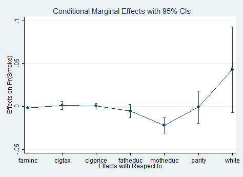

```stata
marginsplot
```

Посмотрим на точность классификации построенной логит-модели. Для этого применяется простая команда:

```stata
estat classification
```

```
running C:\Users\Yuliya\Documents\GitHub\bdemeshev\Econometrics-Rosetta-Stone\julia_work\pro
> file.do . estat classification

Logistic model for smoke

              -------- True --------
Classified |         D            ~D  |      Total
-----------+--------------------------+-----------
     +     |         0             3  |          3
     -     |       161          1027  |       1188
-----------+--------------------------+-----------
   Total   |       161          1030  |       1191

Classified + if predicted Pr(D) >= .5
True D defined as smoke != 0
--------------------------------------------------
Sensitivity                     Pr( +| D)    0.00%
Specificity                     Pr( -|~D)   99.71%
Positive predictive value       Pr( D| +)    0.00%
Negative predictive value       Pr(~D| -)   86.45%
--------------------------------------------------
False + rate for true ~D        Pr( +|~D)    0.29%
False - rate for true D         Pr( -| D)  100.00%
False + rate for classified +   Pr(~D| +)  100.00%
False - rate for classified -   Pr( D| -)   13.55%
--------------------------------------------------
Correctly classified                        86.23%
--------------------------------------------------
```

Построим ROC-кривую, показывающую качество классификации построенной логит-модели.

```stata
lroc
```

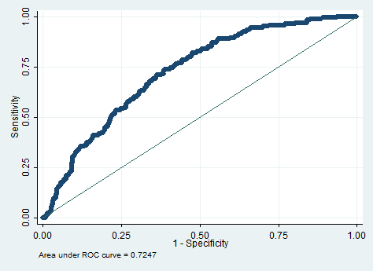

попробуем построить ещё одну логит-модель без учёта фактора `white` и сохраним новую модель под именем `logit_model_new`.

```stata
logit smoke faminc cigtax cigprice fatheduc motheduc parity if fatheduc != . & motheduc != .
est store logit_model_new
```

```
running C:\Users\Yuliya\Documents\GitHub\bdemeshev\Econometrics-Rosetta-Stone\julia_work\pro
> file.do . logit smoke faminc cigtax cigprice fatheduc motheduc parity if fatheduc != . & motheduc !=
>  .

Iteration 0:   log likelihood = -471.77574
Iteration 1:   log likelihood = -435.32968
Iteration 2:   log likelihood = -432.55986
Iteration 3:   log likelihood = -432.55452
Iteration 4:   log likelihood = -432.55452

Logistic regression                               Number of obs   =       1191
                                                  LR chi2(6)      =      78.44
                                                  Prob > chi2     =     0.0000
Log likelihood = -432.55452                       Pseudo R2       =     0.0831

------------------------------------------------------------------------------
       smoke |      Coef.   Std. Err.      z    P>|z|     [95% Conf. Interval]
-------------+----------------------------------------------------------------
      faminc |  -.0151861   .0062608    -2.43   0.015    -.0274571   -.0029151
      cigtax |   .0185624   .0242462     0.77   0.444    -.0289594    .0660842
    cigprice |   .0018681   .0182217     0.10   0.918    -.0338457     .037582
    fatheduc |   -.050238   .0412875    -1.22   0.224    -.1311599    .0306839
    motheduc |  -.2297778   .0489713    -4.69   0.000    -.3257597   -.1337959
      parity |  -.0182503   .0973743    -0.19   0.851    -.2091005    .1725998
       _cons |   1.509398   2.058132     0.73   0.463    -2.524467    5.543263
------------------------------------------------------------------------------
```

Сравним `logit_model` и `logit_model_new` с помощью LR (likelihood-ratio test):

```stata
lrtest logit_model logit_model_new
```

```
running C:\Users\Yuliya\Documents\GitHub\bdemeshev\Econometrics-Rosetta-Stone\julia_work\pro
> file.do . lrtest logit_model logit_model_new

Likelihood-ratio test                                 LR chi2(1)  =      3.00
(Assumption: logit_model_~w nested in logit_model)    Prob > chi2 =    0.0833
```

`p-value = 0.08` в LR-тесте. Следовательно, основная гипотеза о том, что переменная `white` не влияет на решение стать курильщиком, не отвергается на 5% уровне значимости.

Построим пробит-модель и сохраним результат оцененной модели как `probit_model`.

```stata
probit smoke faminc cigtax cigprice fatheduc motheduc parity white if fatheduc != . & motheduc != .
est store probit_model
```

```
running C:\Users\Yuliya\Documents\GitHub\bdemeshev\Econometrics-Rosetta-Stone\julia_work\pro
> file.do . probit smoke faminc cigtax cigprice fatheduc motheduc parity white if fatheduc != . & moth
> educ != .

Iteration 0:   log likelihood = -471.77574
Iteration 1:   log likelihood = -430.54565
Iteration 2:   log likelihood = -429.46543
Iteration 3:   log likelihood = -429.46445
Iteration 4:   log likelihood = -429.46445

Probit regression                                 Number of obs   =       1191
                                                  LR chi2(7)      =      84.62
                                                  Prob > chi2     =     0.0000
Log likelihood = -429.46445                       Pseudo R2       =     0.0897

------------------------------------------------------------------------------
       smoke |      Coef.   Std. Err.      z    P>|z|     [95% Conf. Interval]
-------------+----------------------------------------------------------------
      faminc |  -.0088727   .0033843    -2.62   0.009    -.0155058   -.0022396
      cigtax |   .0058916   .0131832     0.45   0.655    -.0199471    .0317303
    cigprice |   .0035612   .0098119     0.36   0.717    -.0156698    .0227921
    fatheduc |  -.0345932   .0232361    -1.49   0.137    -.0801351    .0109488
    motheduc |  -.1256938   .0271973    -4.62   0.000    -.1789995   -.0723882
      parity |  -.0030532   .0539655    -0.06   0.955    -.1088236    .1027172
       white |   .2423484   .1397166     1.73   0.083    -.0314911    .5161879
       _cons |   .3930625   1.115394     0.35   0.725     -1.79307    2.579195
------------------------------------------------------------------------------
```

Сравним коэффициенты построенных моделей: модели линейной вероятности, логит- и пробит-моделей.

```stata
est tab lin_prob_model logit_model probit_model
```

```
running C:\Users\Yuliya\Documents\GitHub\bdemeshev\Econometrics-Rosetta-Stone\julia_work\pro
> file.do . est tab lin_prob_model logit_model probit_model

-----------------------------------------------------
    Variable | lin_prob~l   logit_mo~l   probit_m~l
-------------+---------------------------------------
_            |
      faminc | -.00148134
      cigtax |  .00083336
    cigprice |  .00074724
    fatheduc | -.00648801
    motheduc | -.02424156
      parity |  .00195649
       white |  .04716033
       _cons |  .42970714
-------------+---------------------------------------
smoke        |
      faminc |              -.01714194   -.00887273
      cigtax |               .01385944     .0058916
    cigprice |               .00415614    .00356118
    fatheduc |              -.05461594   -.03459316
    motheduc |              -.22446651   -.12569383
      parity |              -.00843544   -.00305324
       white |               .43663173    .24234842
       _cons |                .9606284    .39306252
-----------------------------------------------------
```